# Live Session 2

W203, Statistics for Data Science

W203 Team, updated by Oleg Melnikov

Compiled on: Mon May 11 1:36:04 PM 2020

# 1 Random Variable (RV)

[figure not shown]

Did you really just use the binomial distribution for a problem with 3 outcomes

## 1.1 Random Variables Group Discussion

#### 1.1 Exercise:

How do you define a function?

**Answer**

- It’s a binary relation over two sets.
- It maps a point to point.
- It cannot map a point to multiple points

#### 1.1 Exercise:

Which $Y$ is a function of $X$?

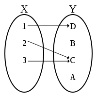

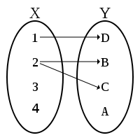

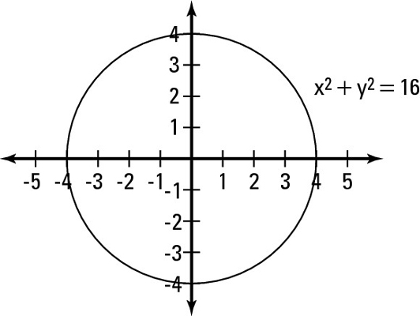

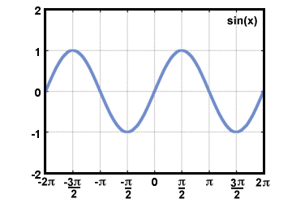

- Which $X$ is a function of $Y$?
- Is $f(x)=1$ a function?

**Answer**

Yes, No, No, Yes, No, Yes

**Domain**, **co-domain**, and **range**

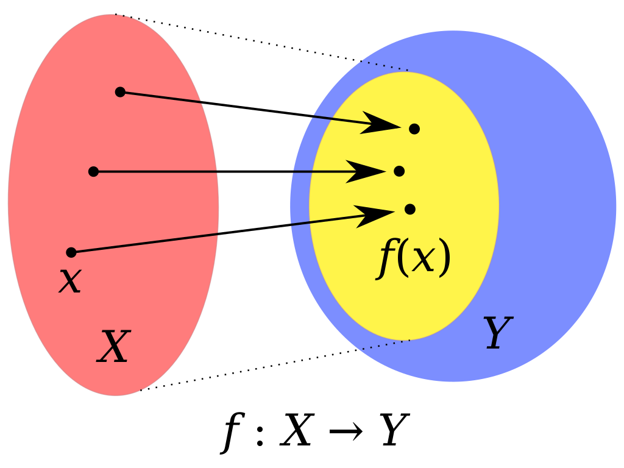

Author: Damien Karrasl

#### 1.1 Exercise:

What is a random variable (RV)?

**Answer**

It’s a real-valued function on sample space, i.e. RV $X:\Omega\to \mathbb{R}$. So, we can say that $X=X(\omega), \forall\omega\in \Omega$

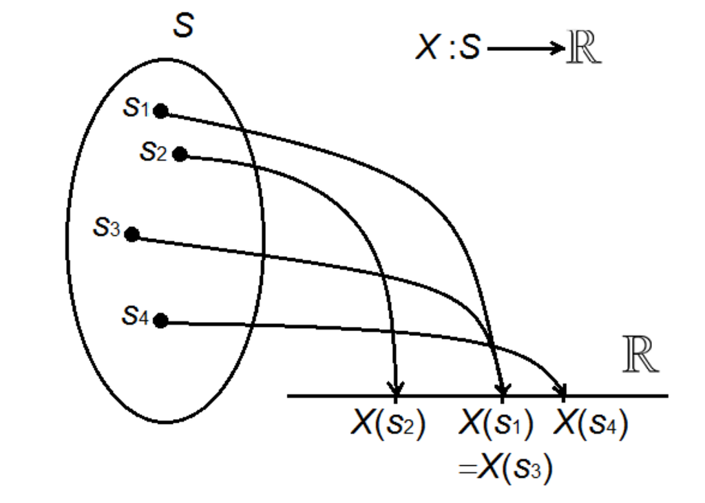

**Experiment:** You blindly retrieve a playing from a deck. Then I generate a number as:

$$X = \begin{cases}
-1 & \text{if card is red } \\
100 & \text{if card is black or spades } \\
0 & \text{any other type}
\end{cases}$$

#### 1.1 Exercise:

1. Is $X$ a random variable (RV) if
   1. has full deck of cards?
   2. has red red cards only
   3. has no cards
2. If so how,
   1. Is it continuous or discrete?
   2. What is its range?
   3. What is Omega?

**Answer**

#### 1.1 Exercise:

Let’s define $Y=X^2$. Is $Y$ an RV?

**Answer**

Well, $Y(X)=Y\circ X$ is now a real-valued function on $\Omega$. So, the composition $Y\circ X:\Omega \to \mathbb{R}$

#### 1.1 Exercise:

1. Is any real valued function $f$ defined on the range (output) of $X$ an RV?

**Answer**

What about $f(X)=1$, i.e. a constant function of $X$?

**Answer**

How does $f(X)=1$ look like geometrically? Note: $f:\text{Range}(X)\to\mathbb{R}$

**Answer**

By the given definition, all of these are RVs, including the trivial RV that always returns 1.

#### 1.1 Exercise:

Where does the randomness in a RV come from?

**Answer**

The randomness comes from $\Omega$. RV itself is a deterministic function.

## 1.2 Modeling a Fair Die

The range of a discrete RV is a discrete set of reals, $O$. Much of the time, the range will simply be a finite set of numbers. For any value $k$ in the range, $0 \leq P(X=k) \leq 1$. The sum over all values k in the range is 1, i.e. $\sum_{k \in O} P(X=k)=1$.

The expected value (or population mean) of a discrete random variable $X$ is the weighted average of the values in the range of $X$.

$$E(X) = \sum_{k \in O} k \cdot P(X=k)$$

One very useful feature of R is its ability to generate random numbers from a wide variety of distributions.

#### 1.2 Exercise:

How can we represent a fair (six-sided) die in R? Do so (Hint: ?sample)

**Answer**

```r
die_values = seq(from=1, to=6)    # equivalently, `1:6`
die_probs  = rep(x=1/6, times=6)
```

So the values are just 1, 2, 3, 4, 5, 6, and the probabilities are 0.167, 0.167, 0.167, 0.167, 0.167, 0.167.

#### 1.2 Exercise:

Let the $X$ represent the result of one role of a 6 sided die. Think of the formula for $E(X)$ and use R to evaluate it.

**Answer**

The formula for $E[X]$ is
$$\sum_{i=1}^{N} x \cdot p(x)$$

```r
x_expected_value <- sum(die_values * die_probs)
```

So the expected value of $X$ is 3.5.

#### 1.2 Exercise:

Let $Y:=X^2$. Think of the formula for $\mathbb{E}Y$ and use R to evaluate it.

**Answer**

As we saw in the book, we can just apply this function to the values of $X$. And so, the expected value is
$$\sum_{i=1}^{N} f(x) \cdot p(x) = x^2 \cdot p(x)$$

```r
y_expected_value <- sum(die_values^2 * die_probs)
```

So the expected value of $Y$ is 15.17.